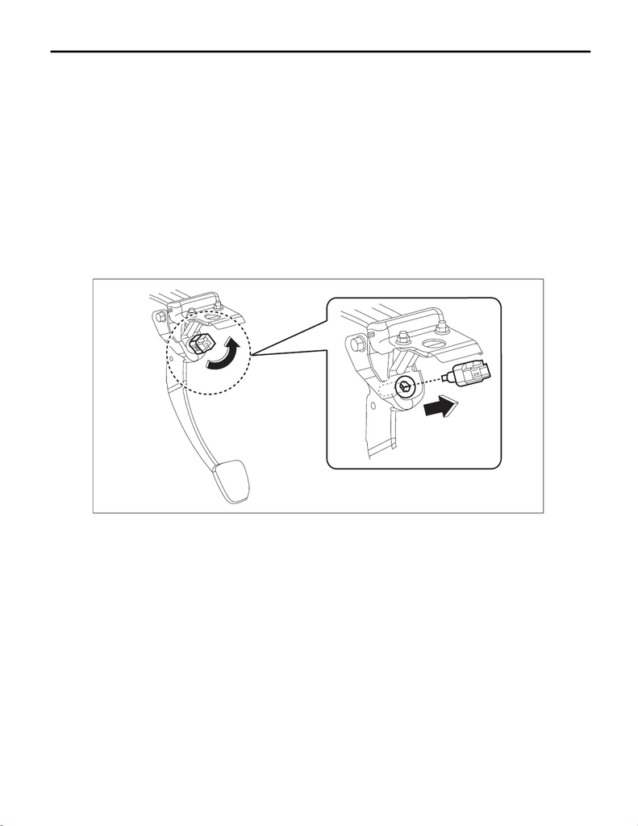

BR-77

Stop Light Switch

BRAKE

15.Stop Light Switch

A: REMOVAL

CAUTION:

Before performing service on the airbag module, always refer to “CAUTION” of “General Descrip-

tion” in “AIRBAG SYSTEM” section. <Ref. to AB-9, CAUTION, General Description.>

1) Disconnect the ground cable from battery and wait for at least 60 seconds before starting work. <Ref. to

NT-5, BATTERY, NOTE, Note.>

NOTE:

For models other than STI model, disconnect the ground terminal from battery sensor.

2) Remove the knee airbag module. <Ref. to AB-35, REMOVAL, Knee Airbag Module.>

3) Remove the cover assembly - instrument panel LWR driver. <Ref. to EI-61, REMOVAL, Instrument Panel

Lower Cover.>

4) Remove the stop light switch.

(1) Disconnect the stop light switch connector.

(2) Remove the stop light switch by turning it counterclockwise.

B: INSTALLATION

1) Install the stop light switch.

(1) Adjust the stop light switch position, and then secure the stop light switch by turning it clockwise. <Ref.

to BR-80, ADJUSTMENT, Stop Light Switch.>

(2) Install the stop light switch connector.

2) Install the knee airbag module.

Tightening torque:

7.5 N·m (0.8 kgf-m, 5.5 ft-lb)

3) Install the cover assembly - instrument panel LWR driver.

4) Connect the battery ground terminal. <Ref. to NT-5, BATTERY, NOTE, Note.>

NOTE:

For models other than STI model, connect the ground terminal to battery sensor.

BR-00961

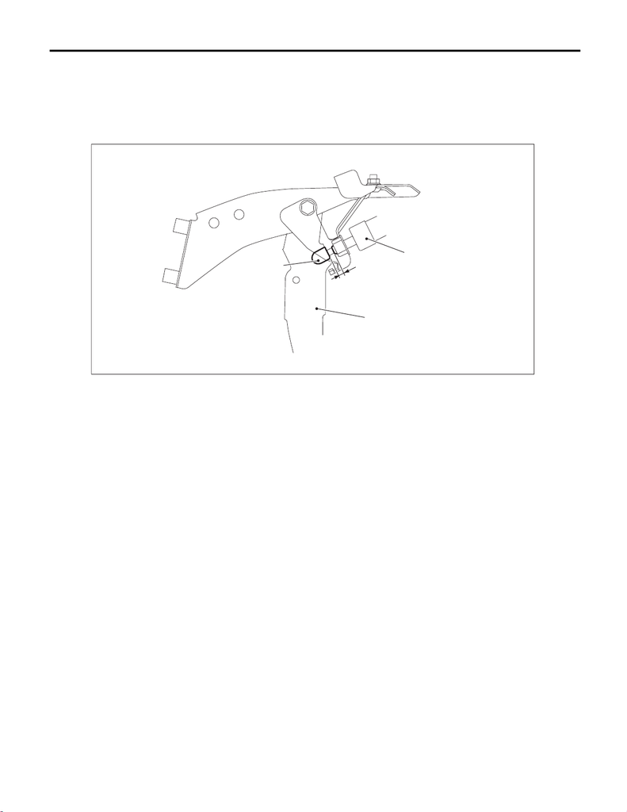

BR-78

Stop Light Switch

BRAKE

C: INSPECTION

1. CLEARANCE CHECK

1) Measure the clearance between the end of the stop light switch and the stopper.

Specification:

Clearance (A) of the stop light switch: 1 mm — 2 mm (0.04 in — 0.08 in)

2) Adjust the position of the stop light switch if the inspection result is not within the standard value. <Ref. to

BR-80, ADJUSTMENT, Stop Light Switch.>

(a) Stop light switch (b) Stopper (c) Brake pedal

(c)

(a)

(b)

(A)

BR-00962

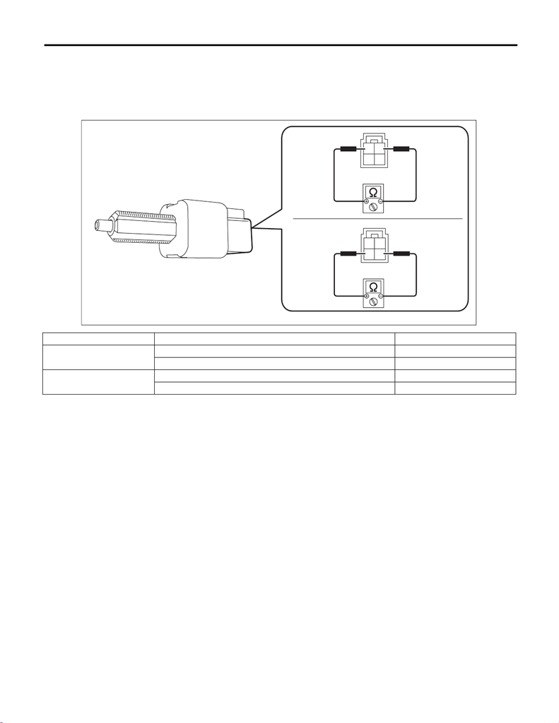

BR-79

Stop Light Switch

BRAKE

2. INSPECT THE RESISTANCE

1) Disconnect the stop light switch connector.

2) Measure the resistance between the stop light switch connector terminals.

Preparation tool:

Circuit tester

3) Replace the stop light switch if the inspection result is not within the standard value.

Terminal No. Inspection conditions Standard

1 — 2

When brake pedal is depressed Less than 1 Ω

When brake pedal is released 1 MΩ or more

3 — 4

When brake pedal is depressed 1 MΩ or more

When brake pedal is released Less than 1 Ω

BR-00965

34

12

34

12

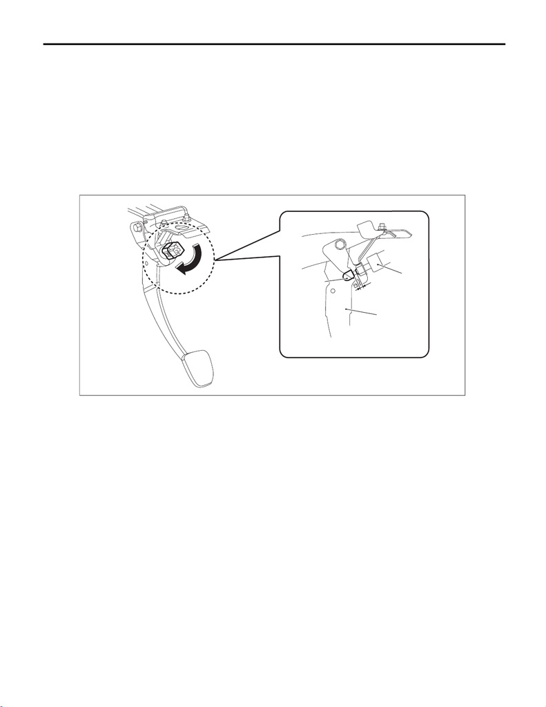

BR-80

Stop Light Switch

BRAKE

D: ADJUSTMENT

1) While pulling up the brake pedal (c) toward you, insert the stop light switch (a) until it reaches the stopper

(b).

2) Install the stop light switch by turning it clockwise.

CAUTION:

• Turn the stop light switch clockwise when installing so that it can return backward by approximate-

ly 1 mm (0.04 in) and clearance is automatically adjusted.

• When pushing the stop light switch against the brake pedal, do not apply excessive force.

• Tighten the stop light switch with a turning torque of 3.0 N·m (0.3 kgf-m, 2.2 ft-lb) or less.

(If it is hard to turn, reduce the switch pushing force and turn it again.)

• Insert until it contacts the stopper, and make sure that clearance (A) of the end of stop light switch

and the stopper is 1 mm — 2 mm (0.04 in — 0.08 in).

(a) Stop light switch (b) Stopper (c) Brake pedal

BR-00963

(c)

(a)

(b)

(A)